# FinalProjectR

install.packages(“chron”) install.packages(“sqldf”) install.packages(“rgdal”) install.packages(“stringr”) install.packages(“rgeos”) install.packages(“dplyr”) install.packages(“Hmisc”) install.packages(“lubridate”) install.packages(“caret”) install.packages(“knncat”) install.packages(“tau”) install.packages(“tidytext”) install.packages(“ngram”) install.packages(“RWeka”)

s3 link to download data is https://s3-us-west-2.amazonaws.com/fds2016sahil/data.txt It is recommended to download data locally first.

```r
library(chron)
library(lubridate)
library(caret)

#df <- read.csv("https://s3-us-west-2.amazonaws.com/fds2016sahil/data.txt")

df <- read.table("data.txt")
```

```r
#Check number of invalid zip codes present
zipCodeDf <- data.frame(as.character(df$Violation.Location..Zip.Code.))
colnames(zipCodeDf) <- "zipCode"

zipCodeLength <- do.call(data.frame, aggregate(cbind(count = zipCode) ~ nchar(as.character(zipCodeDf$zipCode)), data = zipCodeDf, FUN = function(x) c({NROW(x)})))
colnames(zipCodeLength) <- c("ZipCodeLength", "count")
zipCodeLength
```

```
##   ZipCodeLength  count
## 1             1     45
## 2             3      3
## 3             4      1
## 4             5 597067
## 5             6      1
## 6             7      2
## 7             8      1
## 8             9     55
```

```r
#only select the rows where decision hearing result is either against the respondent("IN VIOLATION")
#or for the respondent("DISMISSED")
selected <- c("DISMISSED","IN VIOLATION")
df1 <- df[df$Hearing.Result %in% selected,]
df_unique <- unique(df$Issuing.Agency)
indx <- sapply(df1, is.factor)
#remove dollar sign
df1[indx] <- lapply(df1[indx], function(x)
                            as.character(gsub("\\$", "", x)))
#convert every column to factor
df1<-data.frame(lapply(df1,factor))
#convert date time to Datetime Format
df1$Violation.Date<- as.Date(df1$Violation.Date, "%m/%d/%Y")
df1$Violation.Time <- chron(times. = df1$Violation.Time)


newdf <- data.frame(df1[,c("Violation.Date","Violation.Time","Issuing.Agency","Violation.Location..Borough.", "Hearing.Result", "Hearing.Date", "Total.Violation.Amount", "Scheduled.Hearing.Location", "Hearing.Time", "Compliance.Status" )])
#convert hearing date and time to date time format
newdf$Hearing.Time <- chron(times. = newdf$Hearing.Time)
newdf$Hearing.Date <- as.Date(newdf$Hearing.Date,"%m/%d/%Y")
#remove Issuing Agency, Hearing Location and Violation Locations whose violations are less than 500,10,150
newdf <- newdf[!(as.numeric(newdf$Issuing.Agency) %in% which(table(newdf$Issuing.Agency)<500)),]
newdf <- newdf[!(as.numeric(newdf$Scheduled.Hearing.Location) %in% which(table(newdf$Scheduled.Hearing.Location)<10)),]
newdf <- newdf[!(as.numeric(newdf$Violation.Location..Borough.) %in% which(table(newdf$Violation.Location..Borough.)<150)),]
newdf <- droplevels(newdf)
#convert Violation Amount to numeric
newdf$Total.Violation.Amount <- as.numeric(as.character(newdf$Total.Violation.Amount))
set.seed(22)
pIndex <- createDataPartition(newdf$Issuing.Agency, p = .1,
                                  list = FALSE,
                                  times = 1)
```

```r
newdf <- newdf[pIndex,]
model1 <-glm(Hearing.Result~.,data = newdf,family = 'binomial')
summary(model1)
```

```
##
## Call:
## glm(formula = Hearing.Result ~ ., family = "binomial", data = newdf)
##
## Deviance Residuals:
##     Min       1Q   Median       3Q      Max
## -3.8688  -0.8183   0.2433   0.5954   2.4132
##
## Coefficients:
##                                                Estimate Std. Error z value
## (Intercept)                                   4.909e+00  3.595e+00   1.366
## Violation.Date                                5.602e-03  4.459e-04  12.564
## Violation.Time                                9.366e-02  1.450e-01   0.646
## Issuing.AgencyDEP - BUREAU OF ENV. COMPLIANC  5.245e+00  6.150e-01   8.528
## Issuing.AgencyDEP - IWC                       4.632e+00  7.436e-01   6.229
## Issuing.AgencyDEPT OF TRANSPORTATION          3.382e+00  5.998e-01   5.639
## Issuing.AgencyDEPT. OF BUILDINGS              4.507e+00  5.996e-01   7.517
## Issuing.AgencyDOH MENTAL HEALTH               2.804e+00  6.007e-01   4.668
## Issuing.AgencyDOITT                           2.912e+00  6.795e-01   4.285
## Issuing.AgencyDOS - ENFORCEMENT AGENTS        2.248e+00  5.981e-01   3.758
## Issuing.AgencyFIRE DEPARTMENT OF NYC          5.931e+00  6.021e-01   9.851
## Issuing.AgencyNYPD TRANSPORT INTELLIGENCE DI  3.827e+00  6.190e-01   6.183
## Issuing.AgencyPARKS DEPARTMENT                2.164e+00  6.230e-01   3.473
## Issuing.AgencyPCS - DOHMH                     2.573e+00  6.081e-01   4.232
## Issuing.AgencyPOLICE DEPARTMENT               2.187e+00  6.033e-01   3.625
## Issuing.AgencySANITATION OTHERS               1.875e+00  5.985e-01   3.133
## Issuing.AgencySANITATION POLICE               1.835e+00  6.221e-01   2.950
## Issuing.AgencySANITATION RECYCLING            2.156e+00  6.091e-01   3.540
## Issuing.AgencyVETERINARY-DOHMH                2.057e+00  6.622e-01   3.107
## Violation.Location..Borough.BROOKLYN         -8.094e-02  1.111e-01  -0.729
## Violation.Location..Borough.MANHATTAN        -6.458e-02  1.012e-01  -0.638
## Violation.Location..Borough.QUEENS           -5.999e-02  1.143e-01  -0.525
## Violation.Location..Borough.STATEN IS        -1.733e-01  1.842e-01  -0.941
## Hearing.Date                                 -6.107e-03  4.025e-04 -15.173
## Total.Violation.Amount                       -2.836e-05  1.295e-05  -2.189
## Scheduled.Hearing.LocationBROOKLYN            5.297e-01  1.298e-01   4.081
## Scheduled.Hearing.LocationBY PHONE            8.586e-01  1.609e-01   5.338
## Scheduled.Hearing.LocationMANHATTAN           6.131e-01  1.113e-01   5.510
## Scheduled.Hearing.LocationONE-CLICK           4.363e+00  3.257e-01  13.397
## Scheduled.Hearing.LocationQUEENS              9.061e-01  1.376e-01   6.585
```

[output cut: 41 more lines]

```
## Hearing.Time                                 0.002269 **
## Compliance.StatusBoth Due                    0.925927
## Compliance.StatusCompliance Due              0.899477
## Compliance.StatusPenalty Due                 7.19e-15 ***
## ---
## Signif. codes:  0 '***' 0.001 '**' 0.01 '*' 0.05 '.' 0.1 ' ' 1
##
## (Dispersion parameter for binomial family taken to be 1)
##
##     Null deviance: 20624  on 16283  degrees of freedom
## Residual deviance: 13491  on 16247  degrees of freedom
##   (41 observations deleted due to missingness)
## AIC: 13565
##
## Number of Fisher Scoring iterations: 15
```

We select the predictor columns and put into new dataframe and then replace missing values with modes as knn doesn’t remove missing values by default.

```r
sampledf<-newdf[ , -which(names(newdf) %in% c("Respondent.Last.Name","Balance.Due","Violation.Date", "Violation.Time", "Violation.Details","Paid.Amount","Charge..1..Code.Description", "Compliance.Status","Hearing.Date.1","Violation.Location..Zip.Code.","Hearing.Date","Penalty.Imposed"))]
sampledf <- droplevels(sampledf)

Mode <- function (x, na.rm) {
    xtab <- table(x)
    xmode <- names(which(xtab == max(xtab)))
    if (length(xmode) > 1) xmode <- ">1 mode"
    return(xmode)
}
#impute missing values with mode...
for (var in 1:ncol(sampledf)) {
  sampledf[is.na(sampledf[,var]),var] <- Mode(sampledf[,var], na.rm = TRUE)
}


sampledf$Total.Violation.Amount <- as.numeric(sampledf$Total.Violation.Amount)
```

# Model

Next we start with implementing the algorithms by first splitting the data into 10 folds for k-fold cross validation. Iteratively each fold is used as test set and remaining 9 are used as train. We find accuracy and execution time for each fold.

## K-NN Classification

```r
require(class)
require(knncat)
idx <- createFolds(sampledf$Hearing.Result,k = 10)
sapply(idx, length)
```

```
## Fold01 Fold02 Fold03 Fold04 Fold05 Fold06 Fold07 Fold08 Fold09 Fold10
##   1631   1632   1633   1633   1632   1633   1632   1633   1633   1633
```

```r
accuracy <- vector()
timeknn <- vector()
for (i in 1:10) {
  start.time <- Sys.time()
  #knncat tests for each k value given and selects the model with best k value.
  model <- knncat(sampledf[ -idx[[i]] , ], sampledf[ idx[[i]], ], k=c(1,3,5,7,9,11,13,15,19),classcol = 3)
  end.time <- Sys.time()
  timeknn[i]<-end.time - start.time
  pred <- predict(model,sampledf[ -idx[[i]] , ],sampledf[ idx[[i]], ],train.classcol = 3,newdata.classcol = 3)
  cm <-table(pred,sampledf[ idx[[i]], ]$Hearing.Result)
  accuracy[i]<-sum(diag(cm))/sum(cm)
}
cm
```

```
##
## pred           DISMISSED IN VIOLATION
##   DISMISSED          357          221
##   IN VIOLATION       180          875
```

We carry out similar steps for regression.

```r
accuracylm <- vector()
timelm <- vector()
for (i in 1:10) {
  start.time <- Sys.time()
  model <-glm(Hearing.Result~.,family = binomial,data =sampledf[ -idx[[i]] , ] )
  end.time <- Sys.time()
  timelm[i]<-end.time - start.time
  pred <- predict(model,sampledf[ idx[[i]], ],type = 'response')
  cm <- table(sampledf[ idx[[i]], ]$Hearing.Result, pred>0.5)

  accuracylm[i]<-sum(diag(cm))/sum(cm)
}
cm
```

```
##
##                FALSE TRUE
##   DISMISSED      342  195
##   IN VIOLATION   185  911
```

## Random Forests

We carry out similar steps for Random Forests.

```r
library(randomForest)
accuracyrf <- vector()
timerf <- vector()
for (i in 1:10) {
  start.time <- Sys.time()
  rf <-randomForest(Hearing.Result~.,data =sampledf[ -idx[[i]] , ] ,importance = TRUE)
  end.time <- Sys.time()
  timerf[i]<-end.time - start.time
  pred <- predict(rf,sampledf[ idx[[i]], ])
  cm <- table(sampledf[ idx[[i]], ]$Hearing.Result, pred)
  accuracyrf[i]<-sum(diag(cm))/sum(cm)
}
cm
```

```
##               pred
##                DISMISSED IN VIOLATION
##   DISMISSED          324          213
##   IN VIOLATION       152          944
```

### Importance Plots.

The mean decrease in accuracy a variable causes is determined during the out of bag error calculation phase. The more the accuracy of the random forest decreases due to the exclusion (or permutation) of a single variable, the more important that variable is deemed, and therefore variables with a large mean decrease in accuracy are more important for classification of the data. The mean decrease in Gini coefficient is a measure of how each variable contributes to the homogeneity of the nodes and leaves in the resulting random forest. Each time a particular variable is used to split a node, the Gini coefficient for the child nodes are calculated and compared to that of the original node. The Gini coefficient is a measure of homogeneity from 0 (homogeneous) to 1 (heterogeneous). The changes in Gini are summed for each variable and normalized at the end of the calculation. Variables that result in nodes with higher purity have a higher decrease in Gini coefficient.

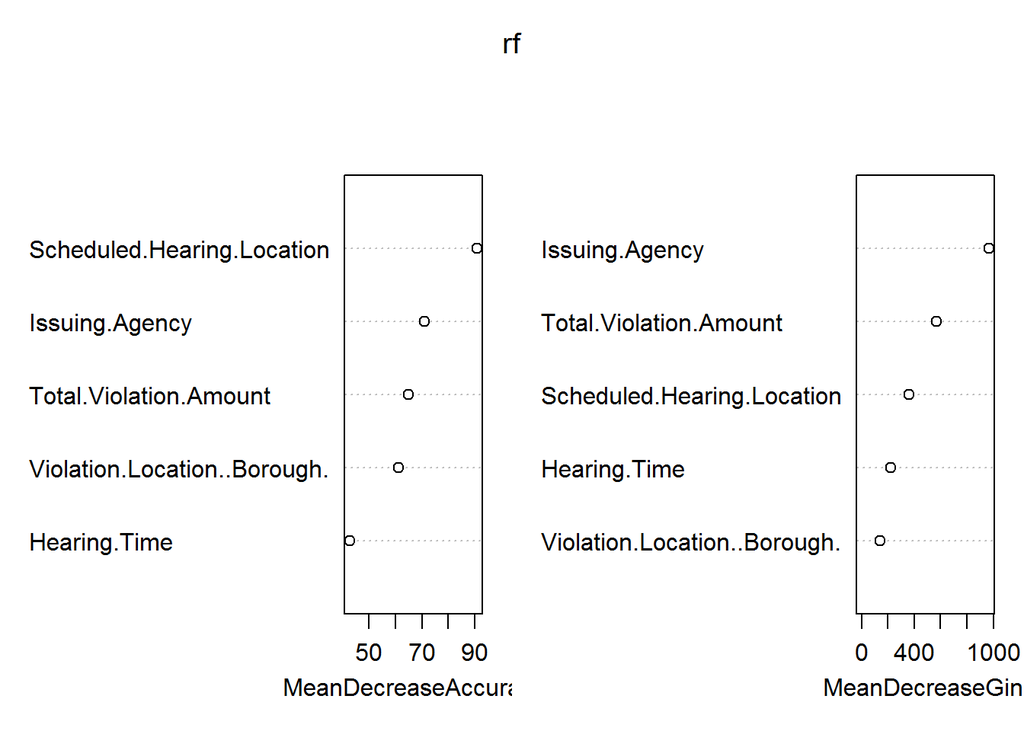

```r
trainIndex <- createDataPartition(sampledf$Hearing.Result, p = .8,
                                  list = FALSE,
                                  times = 1)
traindf <- sampledf[trainIndex,]
rf <- randomForest(Hearing.Result~., data=traindf,  importance = TRUE)
varImpPlot(rf)
```

```r
importance(rf)
```

```
##                              DISMISSED IN VIOLATION MeanDecreaseAccuracy
## Issuing.Agency               52.587970     28.01710             71.06726
## Violation.Location..Borough.  7.631166     48.20523             61.13456
## Total.Violation.Amount       34.639112     24.84023             64.97108
## Scheduled.Hearing.Location   25.194597     63.90546             90.86907
## Hearing.Time                  3.399183     35.89033             42.87467
##                              MeanDecreaseGini
## Issuing.Agency                       969.8218
## Violation.Location..Borough.         139.3574
## Total.Violation.Amount               565.4885
## Scheduled.Hearing.Location           359.4726
## Hearing.Time                         219.0854
```

## SVM Implementation

There are close to 170000 rows in the dataset. Also some description occur less than 10 times. We remove those descriptions. Then similar to the step we did for Issuing Agency we balance split on Code Description and then use that for our ngram analysis.

```r
df2 <- df1[!(as.numeric(df1$Charge..1..Code.Description) %in% which(table(df1$Charge..1..Code.Description)<10)),]
df2 <- droplevels(df2)
pIndex <- createDataPartition(df2$Charge..1..Code.Description, p = .1,
                                  list = FALSE,
                                  times = 1)
dfa <- df2[pIndex,]
```

Let’s create document term matrix for svm implementation

```r
library(tm)
library(SnowballC)
library(tau)
library(RWeka)
descriptions <- data.frame((dfa$Charge..1..Code.Description))
descriptions <- as.character(descriptions$X.dfa.Charge..1..Code.Description.)
documents <- VCorpus(VectorSource(descriptions))
documents <- tm_map(documents,
                     content_transformer(function(x) iconv(x, to='UTF-8', sub='byte')),
                     mc.cores=1)
#remove symbols
toSpace <- content_transformer(function (x , pattern ) gsub(pattern, " ", x))
documents <- tm_map(documents, toSpace, "/",mc.cores = 1)
documents <- tm_map(documents, toSpace, "\\|", mc.cores = 1)
removeURL <- function(x) gsub("http[[:alnum:]]*", "", x)
documents <- tm_map(documents, content_transformer(removeURL))
#convert to lowercase
documents <- tm_map(documents, content_transformer(tolower),mc.cores = 1)
# Remove numbers
documents <- tm_map(documents, removeNumbers,mc.cores = 1)

# Remove punctuations
documents <- tm_map(documents, removePunctuation,mc.cores = 1)

# Remove english common stopwords
documents <- tm_map(documents, removeWords, stopwords("english"))
# specify your stopwords as a character vector
#documents <- tm_map(documents, removeWords, c("pizza","tco","eat"))
# Eliminate extra white spaces
documents <- tm_map(documents, stripWhitespace, mc.cores = 1)
# Text stemming
documents <- tm_map(documents, stemDocument, lazy = T)
#create unigram matrix
dtm <-(DocumentTermMatrix(documents))
```

```r
#Bigrams
BigramTokenizer <- function(x) {RWeka::NGramTokenizer(x, RWeka::Weka_control(min=2, max=2))}
options(mc.cores=1)
dtm2 <- DocumentTermMatrix(documents, control=list(tokenize=BigramTokenizer))
#Trigrams
#ThreegramTokenizer <- function(x) {RWeka::NGramTokenizer(x, RWeka::Weka_control(min=3, max=3))}
#options(mc.cores=1)
#dtm3 <- DocumentTermMatrix(documents, control=list(tokenize=ThreegramTokenizer))
NgramTokenize <- function(x) {RWeka::NGramTokenizer(x, RWeka::Weka_control(min=1, max=2))}
dtmn <- DocumentTermMatrix(documents, control=list(tokenize=NgramTokenize))
trainIndex <- createDataPartition(dfa$Hearing.Result, p = .75,
                                  list = FALSE,
                                  times = 1)
```

```r
m1 <- as.matrix(dtm)#unigram
m2 <- as.matrix(dtm2)#bigram
mn <- as.matrix(dtmn)
df1 <- data.frame(m1,dfa$Hearing.Result) #unigramdf
df2 <- data.frame(m2,dfa$Hearing.Result) #bigramdf
dfn <- data.frame(mn,dfa$Hearing.Result) #bigramdf

names(df1)[names(df1) == 'dfa.Hearing.Result'] <- 'Result'
names(df2)[names(df2) == 'dfa.Hearing.Result'] <- 'Result'
names(dfn)[names(dfn) == 'dfa.Hearing.Result'] <- 'Result'
traindf1 <- df1[trainIndex,]
testdf1 <- df1[-trainIndex,]
traindf2 <- df2[trainIndex,]
testdf2 <- df2[-trainIndex,]

library("e1071")
library("kernlab")
svm_model1 <- svm(Result ~ ., data=traindf1) #unigramdf
pred1 <- predict(svm_model1,testdf1)
cm1 <- table(pred1,testdf1$Result)
cm1
```

```
##
## pred1          DISMISSED IN VIOLATION
##   DISMISSED          193          153
##   IN VIOLATION      1160         2635
```

```r
sum(diag(cm1))/sum(cm1) #Accuracy unigram linear svm
```

```
## [1] 0.6829268
```

```r
svm_model2 <- svm(Result ~ ., data=traindf2)#bigramdf
pred2 <- predict(svm_model2,testdf2)
cm2 <- table(pred2,testdf2$Result)
cm2
```

```
##
## pred2          DISMISSED IN VIOLATION
##   DISMISSED            0            0
##   IN VIOLATION      1353         2788
```

```r
sum(diag(cm2))/sum(cm2) #Accuracy bigram linear svm
```

```
## [1] 0.6732673
```

```r
#rbf kernel
svp <- ksvm(Result~., data= traindf1,type="C-svc",kernel='rbf',kpar=list(sigma=1),C=1)
pred1 <- predict(svp,testdf1)
cm1 <- table(pred1,testdf1$Result)
cm1
```

```
##
## pred1          DISMISSED IN VIOLATION
##   DISMISSED          832          670
##   IN VIOLATION       521         2118
```

```r
sum(diag(cm1))/sum(cm1)#Accuracy unigram rbf kernel
```

```
## [1] 0.7123883
```

```r
svp <- ksvm(Result~., data= traindf2,type="C-svc",kernel='rbf',kpar=list(sigma=1),C=1)
pred2 <- predict(svp,testdf2)
cm2 <- table(pred2,testdf2$Result)
cm2
```

```
##
## pred2          DISMISSED IN VIOLATION
##   DISMISSED          812          658
##   IN VIOLATION       541         2130
```

```r
sum(diag(cm2))/sum(cm2) #Accuracy Bigram rbf
```

```
## [1] 0.7104564
```

# Visualization

First Visualitation is for the Accuracies of 3 of the algorithms i.e Logistic Regression, Random Forest, K-NN Classification.It is a grouped bar plot and we observe the accuracy of Random Forest is slightly better than the other two.  
##Accuracy Comparison

```r
library(reshape2)
folds <- 1:10
mean(accuracyrf)#random forest accuracy averaged across folds
```

```
## [1] 0.7494027
```

```r
mean(accuracylm)#logistic regression acccuracy averaged across folds
```

```
## [1] 0.7355607
```

```r
mean(accuracy)#knn accuracy averaged across folds...
```

```
## [1] 0.7226979
```

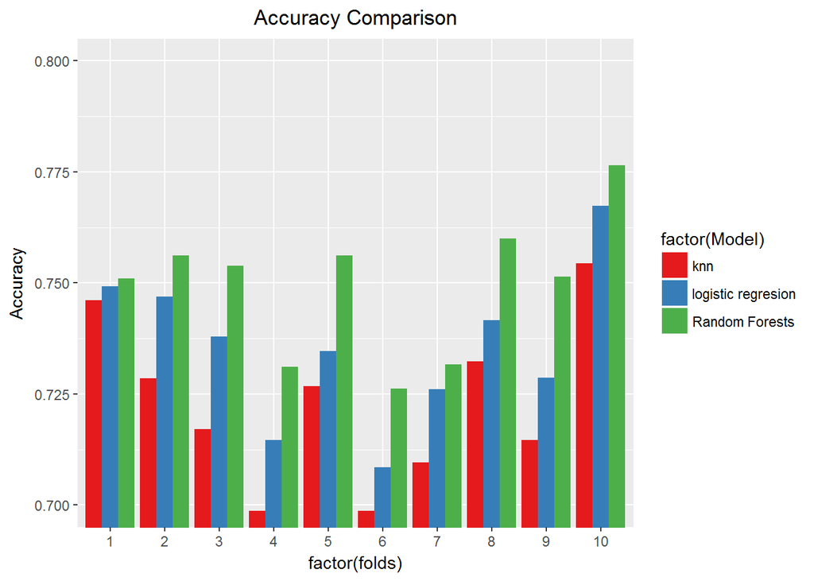

```r
comp<-data.frame(accuracy,accuracylm,accuracyrf,folds)
colnames(comp)<- c("knn","logistic regresion","Random Forests", "folds")
compfull <- melt(comp,id = c("folds"))
colnames(compfull) <- c("folds","Model","Accuracy")
compfull$folds <- as.factor(compfull$folds)
ggplot(compfull, aes(factor(folds), Accuracy, fill = factor(Model)))+
  labs(title="Accuracy Comparison") +
  coord_cartesian(ylim=c(0.7,0.8)) +
  theme(plot.title = element_text(hjust = 0.5))+
  geom_bar(stat="identity", position = "dodge") +
  scale_fill_brewer(palette = "Set1")
```

## Execution Time Comparison

Secondly we identify the execution time of each algorithm and plot them on the grouped bar plot. We find the logistic regression performs the best followed by random forest and knn.

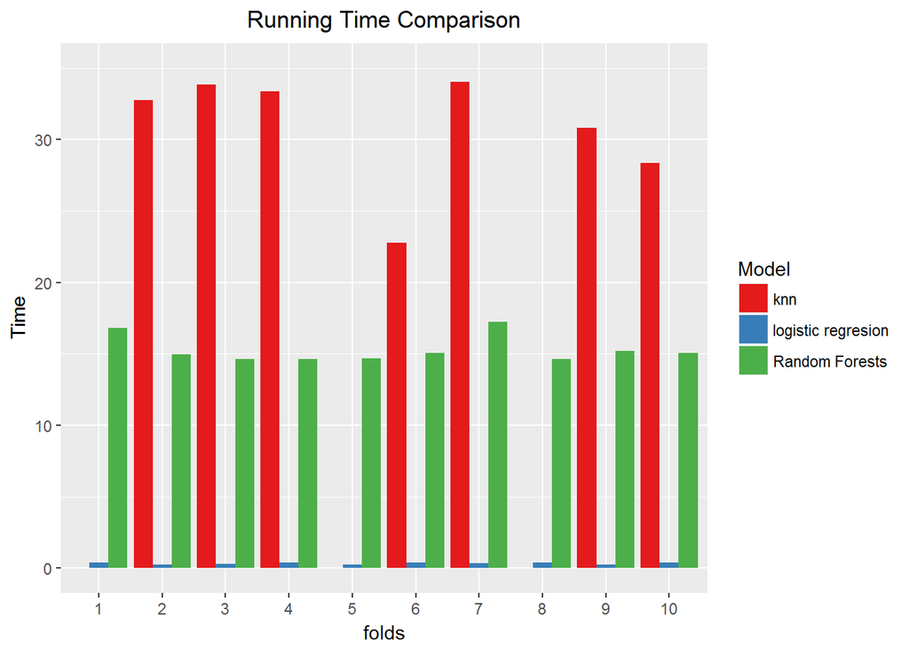

```r
folds <- 1:10
comp<-data.frame(timeknn,timelm,timerf,folds)
colnames(comp)<- c("knn","logistic regresion","Random Forests", "folds")
compfull <- melt(comp,id = c("folds"))
colnames(compfull) <- c("folds","Model","Time")
compfull$folds <- as.factor(compfull$folds)
ggplot(compfull, aes(folds, Time, fill = Model))+labs(title="Running Time Comparison") +ylim(0,35)+
  theme(plot.title = element_text(hjust = 0.5))+
  geom_bar(stat="identity", position = "dodge") +
  scale_fill_brewer(palette = "Set1")
```

## Issuing Agencies Comparison

We plot stacked bar plot of top Issuing Agencies with The violation count on the y axis and the hearing result as the differentiatior. This graph helps us identify the issuing agencies who are more consistent in their Violation tickets and the we can also find out which agency’s violations are dismissed more frequently which signifies they have higher error rate. We observed here that Sanitation issuing agencie’s violations were dismissed more than 50% of time.

```r
dfbar <- sampledf[!(as.numeric(sampledf$Issuing.Agency) %in% which(table(sampledf$Issuing.Agency)<500)),]
dfbar <- droplevels(dfbar)
issuingagency<-data.frame(unique(dfbar$Issuing.Agency),unique(abbreviate(dfbar$Issuing.Agency)))
colnames(issuingagency)<-c("Name","Abbreviation")
issuingagency
```

```
##                             Name Abbreviation
## 1             DEPT. OF BUILDINGS         DEOB
## 2       DOS - ENFORCEMENT AGENTS         D-EA
## 3         FIRE DEPARTMENT OF NYC         FDON
## 4              DOH MENTAL HEALTH         DOMH
## 5         DEPT OF TRANSPORTATION         DEOT
## 6              SANITATION OTHERS         SANO
## 7 DEP - BUREAU OF ENV. COMPLIANC       D-BOEC
## 8              POLICE DEPARTMENT         POLD
```

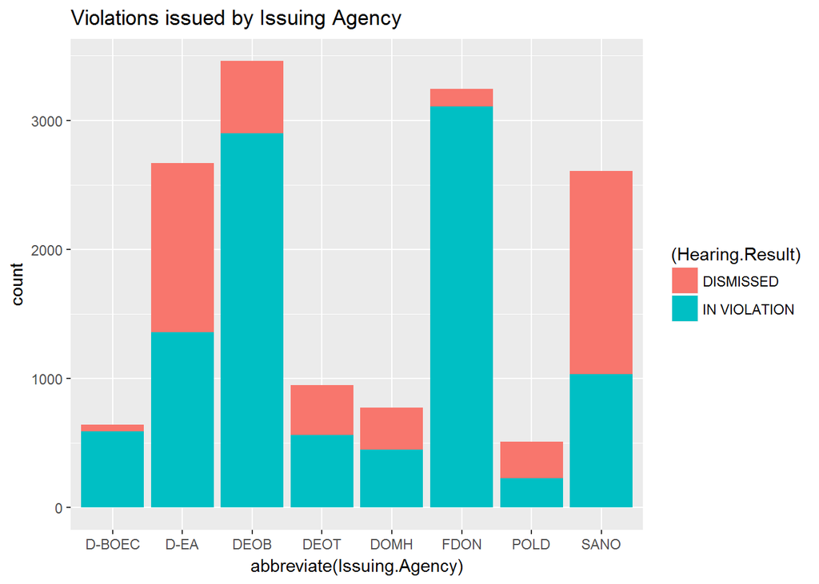

```r
qplot(abbreviate(Issuing.Agency), data=dfbar,geom="bar", fill=(Hearing.Result))+labs(title = "Violations issued by Issuing Agency")
```

## Contribution of n-grams to the outcome

```r
library(dplyr)
library(tidytext)

classes <- data.frame(rownames(dfa),dfa$Hearing.Result)
colnames(classes) <- c("document","result")
dtmn1 <- tidy(dtmn)
mergedtmn <- merge(dtmn1,classes)
dismissed<- dfn[dfn$Result %in% c("DISMISSED"),]
violation <- dfn[dfn$Result %in% c("IN VIOLATION"),]
dtmndis <-as.matrix( dtmn[rownames(dismissed),])
dtmnvio <- as.matrix(dtmn[rownames(violation),])
freqd <- sort(colSums(as.matrix(dtmndis)), decreasing=TRUE)
freqv <- sort(colSums(as.matrix(dtmnvio)), decreasing=TRUE)
head(freqd, 10) #10 most frequent features for Dismissed
```

```
##      dirti     failur       area dirti area   sidewalk     street
##       1115        960        669        652        644        631
##       unit     improp  receptacl     offens
##        615        609        591        516
```

```r
head(freqv, 10) #10 most frequent features for Violation
```

```
##       failur       permit         fail         fire      prevent
##         1594         1494         1351         1219         1157
##      protect         test        dirti fire protect         post
##         1010          992          965          894          822
```

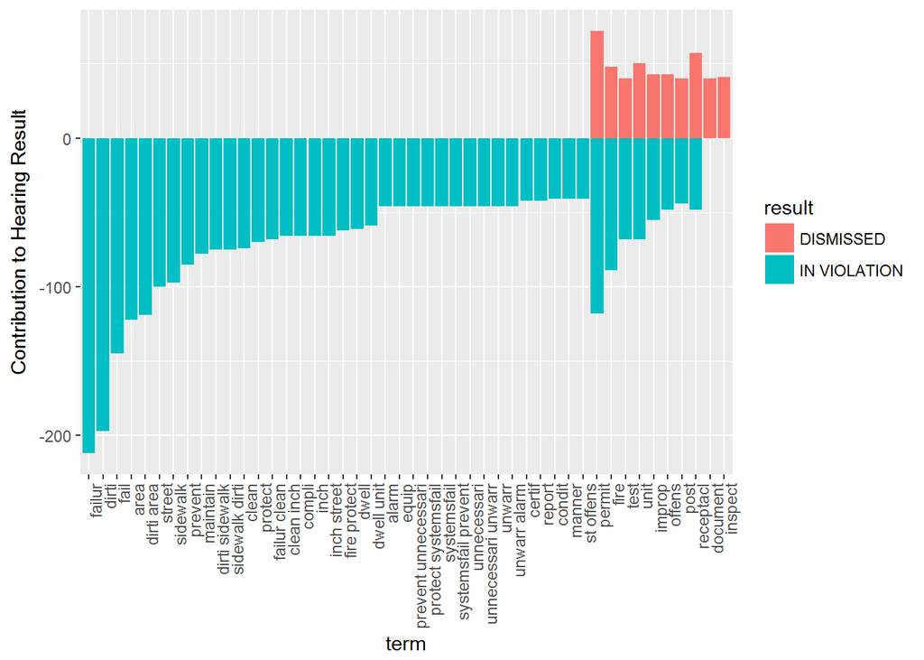

```r
mergedtmn %>%
  count(result, term, wt = count) %>%
  ungroup() %>%
  filter(n >= 40) %>%
  mutate(n = ifelse(result == "IN VIOLATION", -n, n)) %>%
  mutate(term = reorder(term, n)) %>%
  ggplot(aes(term, n, fill = result)) +
  geom_bar(stat = "identity") +
  theme(axis.text.x = element_text(angle = 90, hjust = 1)) +
  ylab("Contribution to Hearing Result")
```

# Find Optimum Penalty Amount

```r
data2015 <- df
#Total records in dataset
nrow(data2015)
```

```
## [1] 641042
```

```r
data2015$Hearing.Status <- as.character(data2015$Hearing.Status)
data2015$Hearing.Result <- as.character(data2015$Hearing.Result)
data2015$Decision.Date <- as.Date(data2015$Decision.Date, format = "%m/%d/%Y")
data2015 <- subset(data2015, Total.Violation.Amount != 0)
```

Finding percentage of violations for each amount

```r
#Select only Total Violation Amount column
data2015Amt <- subset(data2015, Total.Violation.Amount != 0, select = c("Total.Violation.Amount"))
#Total number of violations
ttlViolation <- nrow(data2015Amt)
#Aggregation to find percentage occurenece of each penalty amount
options(scipen = 999)  #To disable scietific notation
ttlAgg <- do.call(data.frame, aggregate(cbind(count = Total.Violation.Amount) ~ Total.Violation.Amount, data = data2015Amt, FUN = function(x) c({round((NROW(x) / ttlViolation) * 100, digits = 4)}, {NROW(x)})))
colnames(ttlAgg) <- c("Total.Violation.Amount", "ttlPercent", "ttlCnt")
```

Find percentage of violations for which amount was paid before decision for each amount

```r
#Select data where Hearing Status is PAID IN FULL and Decision Date is blank. It means that amount has been paid in full before taking any decision
data2015Paid <- subset(data2015, Hearing.Status == "PAID IN FULL" & is.na(Decision.Date) & Total.Violation.Amount != 0, select = c("Total.Violation.Amount"))
#Aggregation  to find percentage occurence of penalty where user has paid fully
paidAgg <- do.call(data.frame, aggregate(cbind(count = Total.Violation.Amount) ~ Total.Violation.Amount, data = data2015Paid, FUN = function(x)c({round((NROW(x) / ttlViolation) * 100, digits = 4)}, {NROW(x)})))
colnames(paidAgg) <- c("Total.Violation.Amount", "paidPercentFromTotal", "paidCount")
```

Join both datasets

```r
#Left join of ttl Percentage and paid percentage
mergeData <- merge(x = ttlAgg, y = paidAgg, by = "Total.Violation.Amount", all.x = TRUE)
#Replace NA with 0
mergeData <- data.frame(apply(mergeData, 2, function(x){replace(x, is.na(x), 0)}))
#Calculate percentage violations per amount where penalty was paid before decision
mergeData$paidPercentPerPenalty <- (mergeData[,"paidCount"] / mergeData[,"ttlCnt"]) * 100
head(mergeData)
```

```
##   Total.Violation.Amount ttlPercent ttlCnt paidPercentFromTotal paidCount
## 1                     25    12.8096  82071               6.9955     44820
## 2                     50     1.6198  10378               0.3804      2437
## 3                     70     0.0009      6               0.0000         0
## 4                     75     0.6515   4174               0.0061        39
## 5                    100    49.6432 318063              17.2051    110233
## 6                    140     0.0086     55               0.0027        17
##   paidPercentPerPenalty
## 1            54.6112512
## 2            23.4823665
## 3             0.0000000
## 4             0.9343555
## 5            34.6575993
## 6            30.9090909
```

Plot data Barplot of amount versus total number of violations for that amount

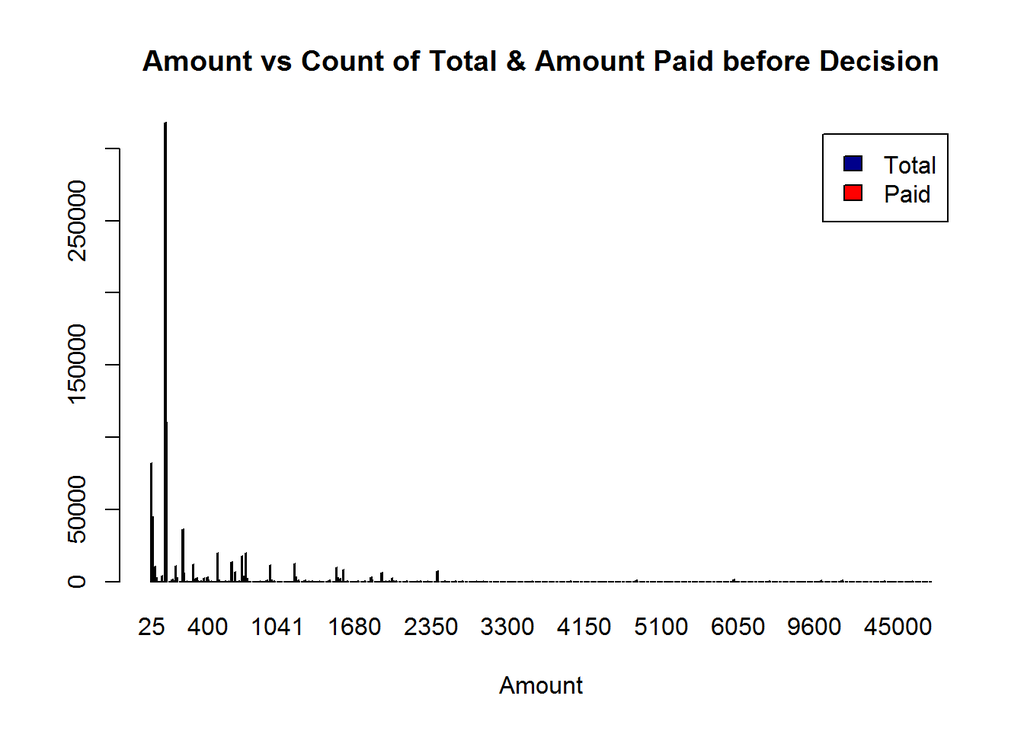

```r
#Barplot
rownames(mergeData) <- mergeData$Total.Violation.Amount
barplot(t(as.matrix(mergeData[,c(3, 5)])), col=c("darkblue","red"), legend=c("Total", "Paid"),ylim=c(0, 320000), xlab = "Amount", main = "Amount vs Count of Total & Amount Paid before Decision", beside=TRUE)
```

We are not able to see proper result because of large data. Even with barplot we are not able to visualize properly. We can divide data into bins to get overall estimation.

```r
library(Hmisc)
```

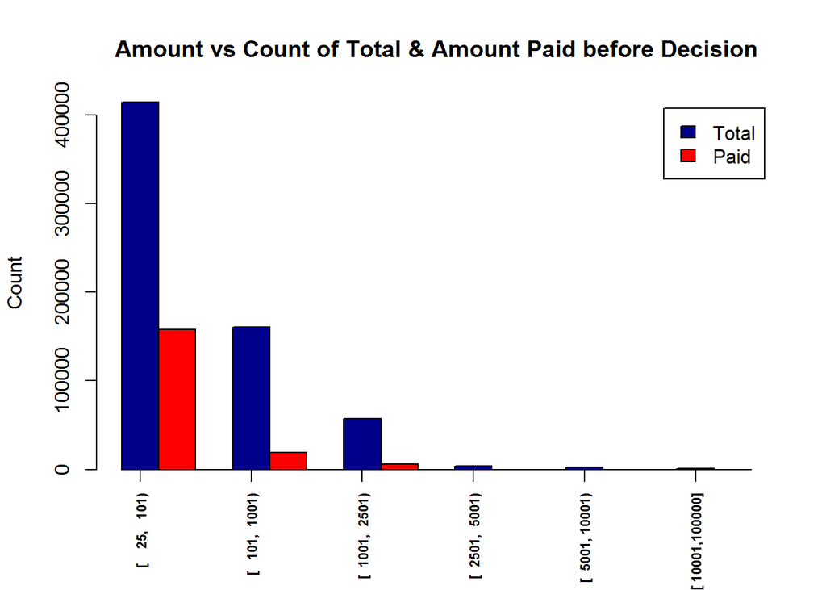

```r
mergeData$amountGrp <- cut2(mergeData$Total.Violation.Amount, c(101, 1001, 2501, 5001, 10001, 100000 ))
mergeDataAgg <- aggregate(mergeData[,c("ttlCnt","paidCount")], by=list(mergeData$amountGrp), "sum")
colnames(mergeDataAgg) <- c("Violation.Amount.Grp",  "ttlCnt", "paidCount")

barPlotData <- t(as.matrix(mergeDataAgg[,c(2,3)]))
names(barPlotData) <- mergeDataAgg[,c(1)]
bar <- barplot(barPlotData, col=c("darkblue","red"), legend=c("Total", "Paid"),ylim=c(0, 420642),ylab = "Count", xlab = "", main = "Amount vs Count of Total & Amount Paid before Decision", beside=TRUE)
axis(1, at=bar[1,], labels=mergeDataAgg[,c(1)], font = 2, cex.axis=0.7, las=3)
```

Plot of amount grouped in bins versus total violations for that bin. We can see from plot that maximum number of times amount was paid before decision when penalty amount was less than or equal to 100.

So lets zoom in there.

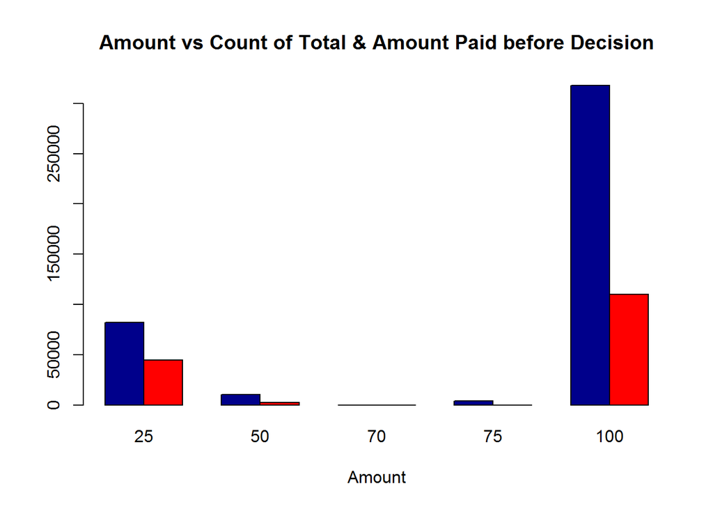

```r
barplot(t(as.matrix(mergeData[mergeData$Total.Violation.Amount <= 100,c(3, 5)])), col=c("darkblue","red"),ylim=c(0, 320000), xlab = "Amount", main = "Amount vs Count of Total & Amount Paid before Decision", beside=TRUE)
```

Plot of amount less than 100 versus total violations for each amount

We can see that for lower penalty amount there is more percentage to pay penalty beofre decison. It is highest for penalty amount $25.

# Revenue Lost over Defaulted Penalties

```r
#How much revenue is lost on defaulted penalties
copyData2015 <- data2015
#Extract month from violation date
copyData2015$Violation.Date <- format(as.Date(as.character(copyData2015$Violation.Date), "%m/%d/%Y"), "%m")
#Select defaulted violations
data15MonthDefaulted <- subset(copyData2015, (Hearing.Status == "DOCKETED" | Hearing.Status == "DEFAULTED") & Hearing.Result == "DEFAULTED", select = c("Violation.Date", "Total.Violation.Amount"))

#Select subset of data for all violations
data15Month <- subset(copyData2015, select = c("Violation.Date", "Total.Violation.Amount"))

#Aggregate default violations
dataMonthDeafaultedAgg <- do.call(data.frame, aggregate(cbind(sum = Total.Violation.Amount) ~ Violation.Date, data = data15MonthDefaulted, FUN = sum))
colnames(dataMonthDeafaultedAgg) <- c("Violation.Month", "DefaultedSum")
#Aggregate all violations
data15MonthAgg <- do.call(data.frame, aggregate(cbind(sum = Total.Violation.Amount) ~ Violation.Date, data = data15Month, FUN = sum))
colnames(data15MonthAgg) <- c("Violation.Month", "ttlSum")
#Join and calculate percentage
mergeData <- merge(x = data15MonthAgg, y = dataMonthDeafaultedAgg, by = "Violation.Month", all.x = TRUE)
mergeData$Violation.Month <- as.character(mergeData$Violation.Month)
(mergeData)
```

```
##    Violation.Month   ttlSum DefaultedSum
## 1               01 19455920      4840670
## 2               02 16503190      4327055
## 3               03 20615880      4604220
## 4               04 22682030      5298790
## 5               05 21348775      4732045
## 6               06 23308255      4296570
## 7               07 25949340      4821335
## 8               08 22797281      4421410
## 9               09 23338085      4137555
## 10              10 26540482      5194755
## 11              11 21422921      3761360
## 12              12 25132550      5255795
```

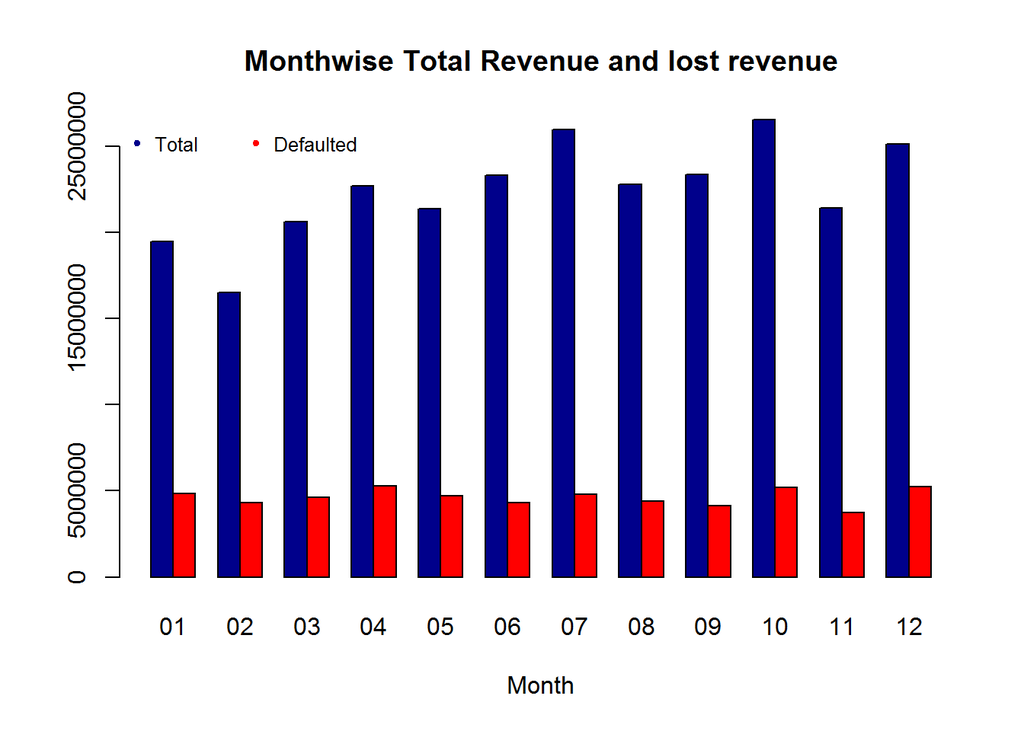

```r
#Plot bargraph
rownames(mergeData) <- mergeData$Violation.Month
barplot(t(as.matrix(mergeData[,c(2,3)])), xlab = "Month", col=c("darkblue","red"), main = "Monthwise Total Revenue and lost revenue", beside=TRUE)

legend("topleft", legend=c("Total", "Defaulted"), pch=20, col=c("darkblue","red"), horiz=TRUE, bty='n', cex=0.8)
```

Above plot shows month versus total revenue and lost revenue over defaulted penalties.

# Find Percentage of Defaulted Violations for Different Features

```r
copyData2015 <- data2015
#Select defaulted violations
data15Defaulted <- subset(copyData2015, (Hearing.Status == "DOCKETED" | Hearing.Status == "DEFAULTED") & Hearing.Result == "DEFAULTED", select = c("Charge..1..Code.Description", "Violation.Location..Zip.Code.", "Respondent.Address..Zip.Code.", "Total.Violation.Amount"))
#Select subset of data for all violations
data15All <- subset(copyData2015, select = c("Charge..1..Code.Description", "Violation.Location..Zip.Code.", "Respondent.Address..Zip.Code.", "Total.Violation.Amount"))

#Aggregate default violations
dataDeafaultedAgg <- do.call(data.frame, aggregate(cbind(DefaultedCount = Total.Violation.Amount) ~ (Charge..1..Code.Description + Violation.Location..Zip.Code. + Respondent.Address..Zip.Code. + Total.Violation.Amount), data = data15Defaulted, FUN = function(x)c({NROW(x)})))

#Aggregate all violations
data15AllAgg <- do.call(data.frame, aggregate(cbind(TotalCount = Total.Violation.Amount) ~ (Charge..1..Code.Description + Violation.Location..Zip.Code. + Respondent.Address..Zip.Code. + Total.Violation.Amount), data = data15All, FUN = function(x)c({NROW(x)})))


#Group by all columns
mergeData <- merge(x = data15AllAgg, y = dataDeafaultedAgg, by = c("Charge..1..Code.Description", "Violation.Location..Zip.Code.", "Respondent.Address..Zip.Code.", "Total.Violation.Amount"), all.x = TRUE)
mergeData <- data.frame(apply(mergeData, 2, function(x){replace(x, is.na(x), 0)}))
mergeData$TotalCount <- as.numeric(as.character(mergeData$TotalCount))
mergeData$DefaultedCount <- as.numeric(as.character(mergeData$DefaultedCount))
mergeData$Violation.Location..Zip.Code. <- (as.character(mergeData$Violation.Location..Zip.Code.))
mergeData$Respondent.Address..Zip.Code. <- (as.character(mergeData$Respondent.Address..Zip.Code.))
```

```r
#Agg by Violation zip code
mergeDataAgg <- aggregate(mergeData[,c("TotalCount", "DefaultedCount")], by = list(mergeData$Violation.Location..Zip.Code.), "sum")
colnames(mergeDataAgg) <-c("Violation.Location..Zip.Code.", "TotalCount", "DefaultedCount")
mergeDataAgg <- mergeDataAgg[(nchar(mergeDataAgg$Violation.Location..Zip.Code.) == 5 & mergeDataAgg$TotalCount >= 100),]
mergeDataAgg$Percentage <- (mergeDataAgg$DefaultedCount/ mergeDataAgg$TotalCount) * 100
top10 <- head(mergeDataAgg[order(mergeDataAgg$Percentage, decreasing = T), c(1,4)], 10)
top10
```

```
##     Violation.Location..Zip.Code. Percentage
## 216                         11693   57.30918
## 215                         11692   56.33929
## 206                         11433   51.17647
## 150                         11233   50.41186
## 69                          10302   50.32945
## 88                          10458   49.92614
## 87                          10457   49.91597
## 104                         10474   49.25637
## 86                          10456   48.71740
## 70                          10303   48.68591
```

```r
#Agg by respondent Zip code
mergeDataAgg <- aggregate(mergeData[,c("TotalCount", "DefaultedCount")], by = list(mergeData$Respondent.Address..Zip.Code.), "sum")
colnames(mergeDataAgg) <-c("Respondent.Address..Zip.Code.", "TotalCount", "DefaultedCount")
mergeDataAgg <- mergeDataAgg[(nchar(mergeDataAgg$Respondent.Address..Zip.Code.) == 5 & mergeDataAgg$TotalCount >= 100),]
mergeDataAgg$Percentage <- (mergeDataAgg$DefaultedCount/ mergeDataAgg$TotalCount) * 100
top10 <- head(mergeDataAgg[order(mergeDataAgg$Percentage, decreasing = T), c(1,4)], 10)
top10
```

```
##      Respondent.Address..Zip.Code. Percentage
## 1108                         11693   61.06080
## 1106                         11692   58.18686
## 617                          10457   54.43582
## 588                          10303   54.19383
## 618                          10458   52.77442
## 587                          10302   52.00000
## 695                          10583   50.76142
## 1023                         11433   50.74113
## 616                          10456   50.20475
## 586                          10301   49.19379
```

```r
#Agg by Amount
mergeDataAgg <- aggregate(mergeData[,c("TotalCount", "DefaultedCount")], by = list(mergeData$Total.Violation.Amount), "sum")
colnames(mergeDataAgg) <-c("Total.Violation.Amount", "TotalCount", "DefaultedCount")
mergeDataAgg <- mergeDataAgg[(mergeDataAgg$TotalCount >= 100),]
mergeDataAgg$Percentage <- (mergeDataAgg$DefaultedCount/ mergeDataAgg$TotalCount) * 100
top10 <- head(mergeDataAgg[order(mergeDataAgg$Percentage, decreasing = T), c(1,2, 4)], 10)
top10
```

```
##     Total.Violation.Amount TotalCount Percentage
## 4                       75       3996   77.75275
## 194                  12000        706   64.30595
## 165                   6000       1523   60.21011
## 7                      150        995   55.97990
## 10                     250      27784   55.58955
## 13                     300      12075   42.61698
## 5                      100     308884   32.22893
## 119                   4000        234   32.05128
## 34                    1000       9957   28.47243
## 14                     350       1917   28.11685
```

# Clean Neighborhoods

Find cleanliness related words and filter data based on those words

```r
#Find out all violations related data from
dataCleanLabel <- subset(data2015, Dirty.Label == 1 & Charge..1..Code.Description != "", select = c("Charge..1..Code.Description"))
library(tm)
dataCleanLabel <- as.vector(dataCleanLabel)
dataCleanCorpus <- VCorpus(VectorSource(dataCleanLabel))
dataCleanCorpus <- tm_map(dataCleanCorpus, removeWords, stopwords("english"))
dataCleanCorpus <- tm_map(dataCleanCorpus,  removePunctuation)
dataCleanCorpus <- tm_map(dataCleanCorpus, content_transformer(tolower))
dataCleanCorpus <- tm_map(dataCleanCorpus, stripWhitespace)

library(ngram)
library(RWeka)
UnigramTokenizer <- function(x) NGramTokenizer(x, Weka_control(min = 1, max = 1))
dtm <- DocumentTermMatrix(dataCleanCorpus, control = list(tokenize = UnigramTokenizer, wordLengths = c(3,10)))

dtmFrame <- as.data.frame( t(as.matrix(  dtm )) )
dtmFrame$Term <- rownames(dtmFrame)
colnames(dtmFrame) <- c("count", "Term")

top30 <- head(dtmFrame[order(dtmFrame$count, decreasing = T), c(1, 2)], 30)
top30
```

```
##             count       Term
## dirty      162279      dirty
## area        92232       area
## units       77817      units
## collection  76524 collection
## for         76494        for
## failure     71880    failure
## clean       61024      clean
## into        60375       into
## dwelling    54340   dwelling
## sidewalk    54086   sidewalk
## offense     53480    offense
## 1st         52655        1st
## street      44298     street
## inches      43218     inches
## improper    42831   improper
## nonrecyc    42176   nonrecyc
## storage     37573    storage
## recyc       35619      recyc
## placed      34344     placed
## disposal    34190   disposal
## properly    26615   properly
## out         26604        out
## put         26571        put
## recycs      26293     recycs
## rubbish     23838    rubbish
## loose       23679      loose
## 2nd         23327        2nd
## dirt        20768       dirt
## bedding     20723    bedding
## sidewalks   20609  sidewalks
```

```r
#We uused unigram to verify words selected for selecting all the violations related to cleanliness

dataClean <- subset(data2015, Hearing.Result == "IN VIOLATION")
words <- c("clean", "receptacle", "dirty", "rubbish", "dirt", "waste", "garbage", "litter", "disposal", "dumping", "mosquito", "smoke")
dataClean <- dataClean[ifelse (rowSums(sapply(words, grepl, data2015$Charge..1..Code.Description, ignore.case = TRUE)) > 0, TRUE, FALSE),]
library(stringr)
dataClean$Charge..1..Code.Description <- str_trim(dataClean$Charge..1..Code.Description)

#Group by violation zip code and take count
dataCleanAgg <- do.call(data.frame, aggregate(cbind(count = Violation.Location..Zip.Code.) ~ Violation.Location..Zip.Code., data = dataClean, FUN = function(x) c({NROW(x)})))
colnames(dataCleanAgg) <- c("ZIPCODE", "count")
library(ggplot2)
library(Hmisc)
dataCleanAgg <- subset(dataCleanAgg, nchar(as.character(dataCleanAgg$ZIPCODE)) == 5)
dataCleanAgg$countGrp <- cut2(dataCleanAgg$count, c(0, 1, 100, 300, 600, 1000, 4000))
```

read shape file data You can either use attached ZIP_CODE_040114 folder or download data from https://github.com/mugdhachaudhari/ExternalFactorEffectOnOATHHearing/tree/master/ZIP_CODE_040114

```r
library(rgdal)
nyc <- readOGR(dsn = "ZIP_CODE_040114", layer = "ZIP_CODE_040114")
```

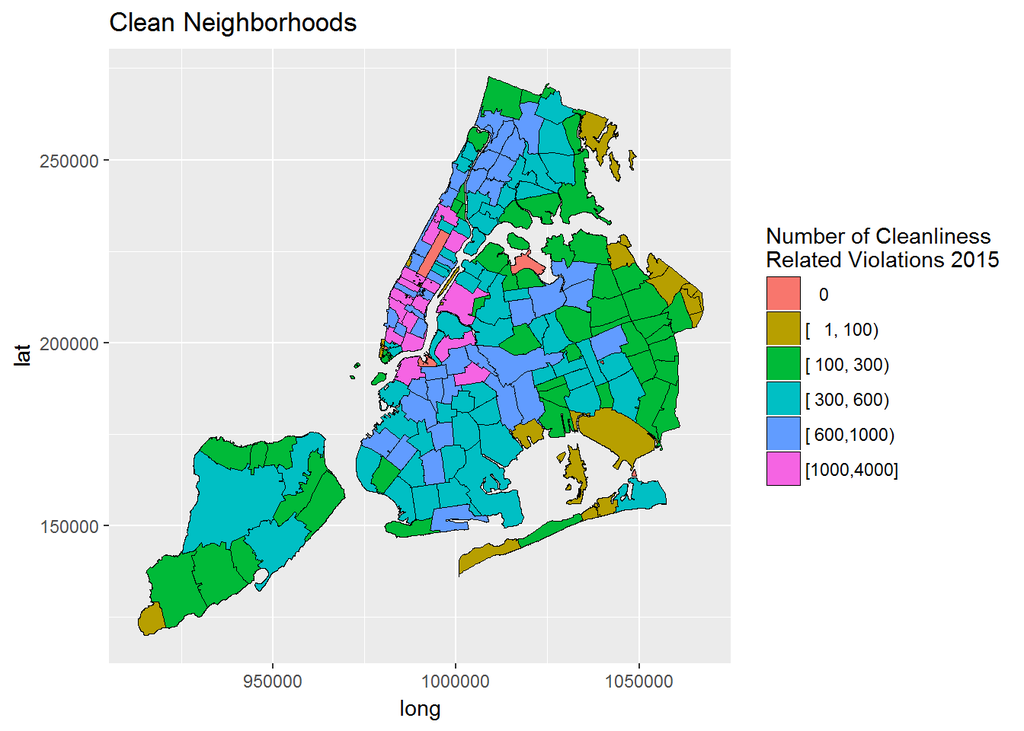

```r
nyc$id <- row.names(nyc)

#Left join with shape file data Ignoring Blank, 0 zipcodes from violation data
nyc@data <- merge(x = nyc@data, y = dataCleanAgg, by = "ZIPCODE", all.x = TRUE)
#Replacing NAs with group 1 to include 0 violations.
nyc@data <- data.frame(apply(nyc@data, 2, function(x){replace(x, is.na(x), "   0")}))

#Plot map
library(rgeos)
nyc_f <- fortify(nyc)
library(dplyr)
nyc_f <- left_join(nyc_f, nyc@data)
map <- ggplot() +
geom_polygon(data = nyc_f, aes(x = long, y = lat, group = group, fill = countGrp), color = "black", size = 0.25) +
coord_equal() +
labs(fill = "Number of Cleanliness\nRelated Violations 2015") +
ggtitle("Clean Neighborhoods")
map
```

We can see in this map that neighborhoods with high cleanliness related violations(Sky blue, Blue) are clustered together. Plotting this data on map helped us to identify those clusters and based on it we can narrow down the factors contributing to it. Manhattan seems to be most unsanitary neighborhood which is correlated with high population of manhattan.

Generate all dates for year 2015

```r
#Generate all dates for year 2015
dateSeq <- data.frame(seq(as.Date("2015/01/01"), as.Date("2015/12/31"), by = "day"))
colnames(dateSeq) <- c("Violation.Date")
dateSeq$Violation.Date <- as.Date(dateSeq$Violation.Date, format = "%Y-%m-%d")
```

Pick top two zipcodes where violations are most.

```r
head(dataCleanAgg[order(as.numeric(dataCleanAgg$count), decreasing = T), ], 2)
```

```
##    ZIPCODE count    countGrp
## 19   10019  1705 [1000,4000]
## 5    10003  1571 [1000,4000]
```

Filter data for zipcode 10019

```r
dataCleanSub <- subset(dataClean, Violation.Location..Zip.Code. == 10019, select = c("Violation.Date"))
dataCleanSub$Violation.Date <- as.Date(as.character(dataCleanSub$Violation.Date), "%m/%d/%Y")
dataCleanSubCnt <- data.frame(table(dataCleanSub))
colnames(dataCleanSubCnt) <- c("Violation.Date", "count")
dataCleanSubCnt$Violation.Date <- as.Date(dataCleanSubCnt$Violation.Date, format = "%Y-%m-%d")
mergeDateViolations <- merge(x = dateSeq, y = dataCleanSubCnt, by = "Violation.Date", all.x = TRUE)
#Replace NA with 0
mergeDateViolations <- data.frame(apply(mergeDateViolations, 2, function(x){replace(x, is.na(x), 0)}))
```

Plot timeseries for 10019

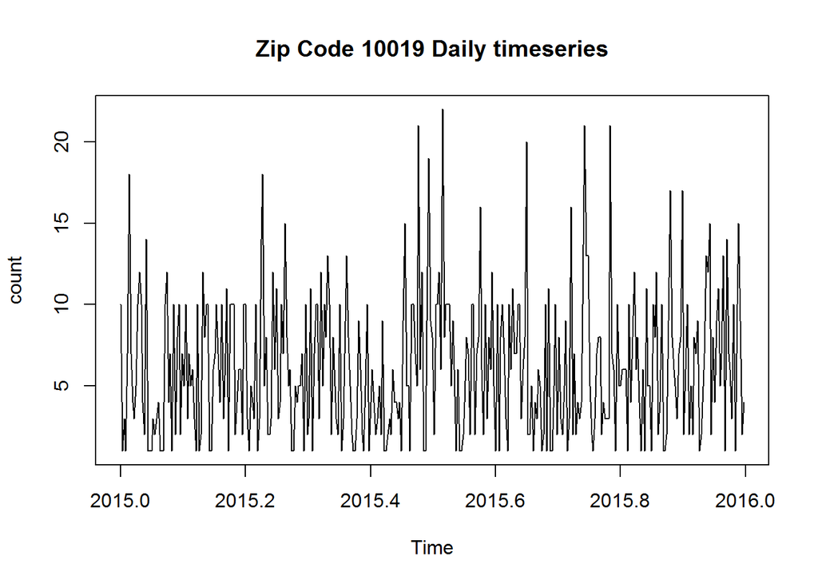

```r
#Daily
plot(ts(mergeDateViolations$count, start = c(2015, 1), frequency = 365), ylab = "count", main = "Zip Code 10019 Daily timeseries")
```

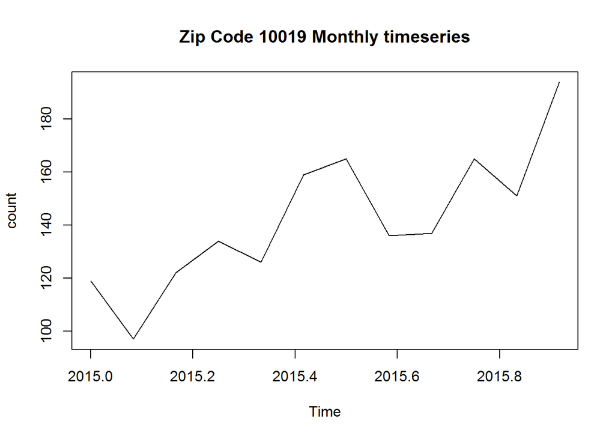

```r
#Monthly
mergeDateViolations$Month <-
format(as.Date(mergeDateViolations$Violation.Date), "%m-%Y")
mergeDateViolations$count <- as.numeric(as.character(mergeDateViolations$count))

mergeMonthViolations <- aggregate(mergeDateViolations[,c("count")], by=list(mergeDateViolations$Month), "sum")
colnames(mergeMonthViolations) <- c("Month", "count")

plot(ts(mergeMonthViolations$count, start = c(2015, 1), frequency = 12), ylab = "count", main = "Zip Code 10019 Monthly timeseries")
```

Above two timeseries are daily and monthly time series for zip code 10019. We can conclude from monthly time series that cleanlinees related violations are low during start of year and it is increasing in periods during rest of the year.

Decompose time series for zip code 10019

```r
library(forecast)
```

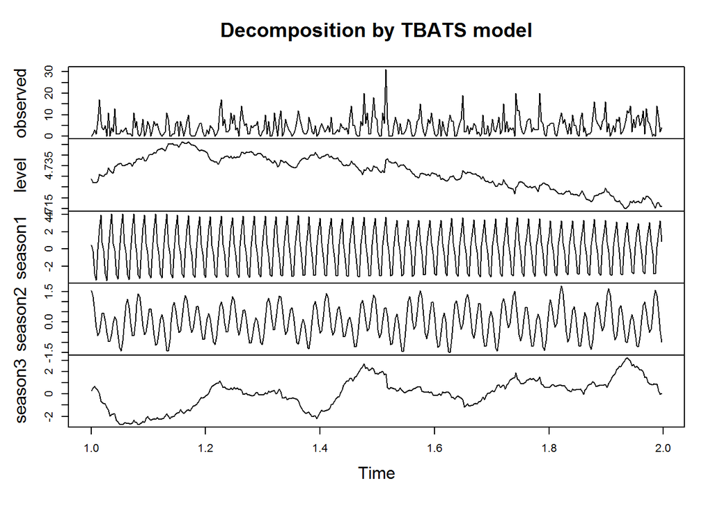

```r
weeklyAndMonthly <- msts(mergeDateViolations$count, seasonal.periods = c(7, 30, 365.25))
seasonalPattern <- tbats(weeklyAndMonthly)
#Zipcode 10019
plot(seasonalPattern)
```

It shows decomposition of timeseries. tbats helps us to capture dynamic multi seasonality. Season 1, season 2, season 3 indicates weekly, monthly and yearly seasonality respectively. We can conclude from weekly timeseries that there is peak at each week. It might be because issuing agency would be reporting violations on any particular day of a week.

Filter data for zip code 10003

```r
dataCleanSub <- subset(dataClean, Violation.Location..Zip.Code. == 10003, select = c("Violation.Date"))
dataCleanSub$Violation.Date <- as.Date(as.character(dataCleanSub$Violation.Date), "%m/%d/%Y")
dataCleanSubCnt <- data.frame(table(dataCleanSub))
colnames(dataCleanSubCnt) <- c("Violation.Date", "count")
dataCleanSubCnt$Violation.Date <- as.Date(dataCleanSubCnt$Violation.Date, format = "%Y-%m-%d")
mergeDateViolations <- merge(x = dateSeq, y = dataCleanSubCnt, by = "Violation.Date", all.x = TRUE)
#Replace NA with 0
mergeDateViolations <- data.frame(apply(mergeDateViolations, 2, function(x){replace(x, is.na(x), 0)}))
```

Plot timeseries for zip code 10003

[figure not shown]

```r
#Daily
plot(ts(mergeDateViolations$count, start = c(2015, 1), frequency = 365), ylab = "count", main = "Zip Code 10019 Daily timeseries")
```

[figure not shown]

```r
#Monthly
mergeDateViolations$Month <-
format(as.Date(mergeDateViolations$Violation.Date), "%m-%Y")
mergeDateViolations$count <- as.numeric(as.character(mergeDateViolations$count))

mergeMonthViolations <- aggregate(mergeDateViolations[,c("count")], by=list(mergeDateViolations$Month), "sum")
colnames(mergeMonthViolations) <- c("Month", "count")

plot(ts(mergeMonthViolations$count, start = c(2015, 1), frequency = 12), ylab = "count", main = "Zip Code 10019 Monthly timeseries")
```

Decompose time series for zip code 10003

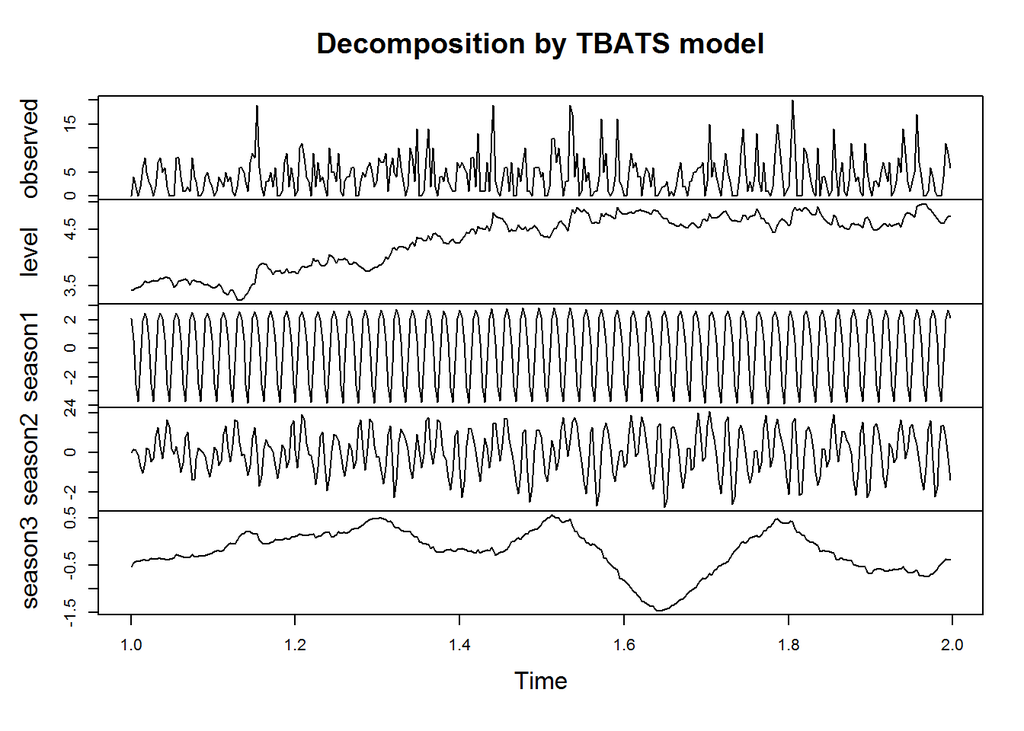

```r
library(forecast)
weeklyAndMonthly <- msts(mergeDateViolations$count, seasonal.periods = c(7, 30, 365.25))
seasonalPattern <- tbats(weeklyAndMonthly)
#Zipcode 10019
plot(seasonalPattern)
```

It is same as zip code 10019 which we have show before. It shows decomposition of timeseries. tbats helps us to capture dynamic multi seasonality. Season 1, season 2, season 3 indicates weekly, monthly and yearly seasonality respectively. We can conclude from weekly timeseries that there is peak at each week. It might be because issuing agency would be reporting violations on any particular day of a week.